# 2024 NH3-loss Statistical Models

Maarit Mäenpää + NJH

2026-01-07

## Model A_base

To reduce the number of parameters in the statistical model, we categorised different fertilisers into categories consisting of;

**Urea**: Fertilisers where the main component was urea

**UAN**: UAN

**ammonium+1**: Fertilisers including a low percentage of ammonium

**ammonium+2**: Fertilisers with higher percentage of ammonium

The table below depicts the categorisation of fertilisers, and the number of observations in each sub-category.

```
##   Fertiliser    N
## 1      urea+ 1729
## 2        UAN  128
## 3 ammonium+1  365
## 4 ammonium+2  374
```

In Model A_Base, we examined the effects of application method (Application), measurement method (Method), and location of study (Place) on NH3 emissions. The tables below show the number of observations within each category examined.

```
##    Application    N
## 1    Broadcast 1771
## 2 Incorporated  344
## 3     Injected   14
## 4       Liquid  467
```

```
##                Method    N
## 1            Micromet  205
## 2                 15N    5
## 3      Closed chamber  774
## 4         Drager-Tube  161
## 5           Semi-open  148
## 6 Ventilated chambers 1032
## 7          Windtunnel  271
```

```
##     Place    N
## 1 Outdoor 1411
## 2     Lab 1185
```

Table below shows counts of all categories of variables:

```
##
##                       Outdoor Lab
##   Micromet                205   0
##   15N                       5   0
##   Closed chamber          369 405
##   Drager-Tube             161   0
##   Semi-open               148   0
##   Ventilated chambers     259 773
##   Windtunnel              264   7
```

```
##
##                Outdoor  Lab
##   Broadcast       1031  740
##   Incorporated     148  196
##   Injected          14    0
##   Liquid           218  249
```

```
##
##          Outdoor  Lab
##   Arable     713   17
##   Grass      320   12
##   None       360 1156
##   Other       18    0
```

```
## , ,  = Micromet,  = Outdoor
##
##
##              Broadcast Incorporated Injected Liquid
##   urea+            128            5        0     16
##   UAN                0            0        0     31
##   ammonium+1        20            0        0      0
##   ammonium+2         0            0        0      5
##
## , ,  = 15N,  = Outdoor
##
##
##              Broadcast Incorporated Injected Liquid
##   urea+              5            0        0      0
##   UAN                0            0        0      0
##   ammonium+1         0            0        0      0
##   ammonium+2         0            0        0      0
##
## , ,  = Closed chamber,  = Outdoor
##
##
##              Broadcast Incorporated Injected Liquid
##   urea+            171           33        0     36
##   UAN                0            0        0     39
##   ammonium+1        16            3        0     10
##   ammonium+2        53            6        0      2
##
## , ,  = Drager-Tube,  = Outdoor
##
##
##              Broadcast Incorporated Injected Liquid
##   urea+             78           34        0     36
##   UAN                0            0        0      0
##   ammonium+1         4            6        0      0
##   ammonium+2         3            0        0      0
##
## , ,  = Semi-open,  = Outdoor
##
##
##              Broadcast Incorporated Injected Liquid
```

[output cut: 70 more lines]

```
##
##              Broadcast Incorporated Injected Liquid
##   urea+            312           92        0    129
##   UAN                0            0        0     16
##   ammonium+1        72           33        0      1
##   ammonium+2       110            1        0      7
##
## , ,  = Windtunnel,  = Lab
##
##
##              Broadcast Incorporated Injected Liquid
##   urea+              6            1        0      0
##   UAN                0            0        0      0
##   ammonium+1         0            0        0      0
##   ammonium+2         0            0        0      0
```

We analysed the effects of Fertiliser types (Urea, UAN, ammonium+1, and ammonium+2), Application method (Broadcast, Liquid, Incorporated, and Injected), the measurement method (Micromet, 15N, Closed chamber, Drager-Tube, Semi-open, Ventilated chambers, and Windtunnel), and whether the study was conducted in the field or in the laboratory, using a general linear mixed effects model (lmer, R-package lme4, Bates et al. 2015). Because the observations originated from different studies, each study most often contributing more than one observation, the reference for study was used as a random effect, to account for non-independence due to repeated measurements.

We used NH3-loss (%), calculated as relative difference between ammonia emissions from a test site and a control site proportional to the control, as a response variable. There were 19 negative observations out of the total 2596.

The frequency distribution of the untransformed NH3-loss measurements is shown below.

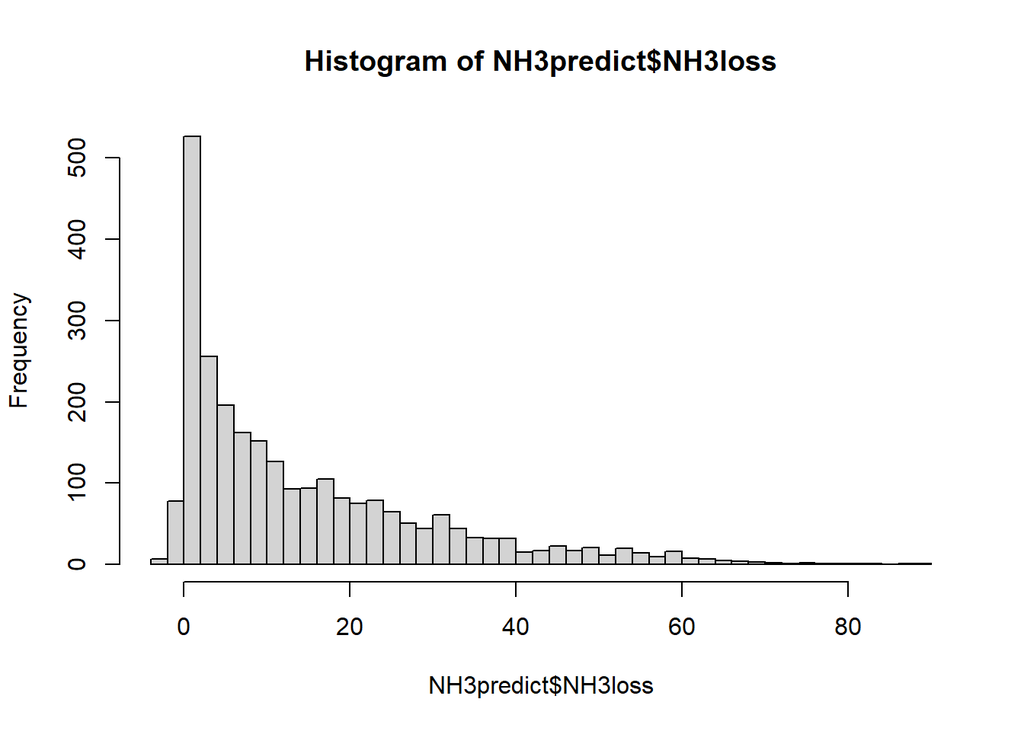

To account for non-normality, the response variable was transformed with a square root transformation. We applied a constant of 4 to allow the analysis to include negative values.

To account for heteroscedasticity, we used weighted ordinary least squares (WOLS, Olvera Astivia & Bruno 2019). We built a vector giving larger weight to observations with smaller variation. To this end, we extracted absolute residuals and fitted values from an unweighted version of Model A_Base (see below for code). We then applied a regression model between the absolute residuals (response variable and fitted values (predictor variable), to estimate the relationship between the amount of variation and the data and the model estimates. To attain a vector with higher values attached to lower variation, we used the inverse of the relationship estimated in the regression model. The weights correspond to increased weight with decrease in variation, thus giving more precedence to more accurate data.

The R-code for the acquiring the weights, and the final model is shown below.

```r
## MODEL A_Base

# Model for calculating weights
model <- lmer(sqrt(NH3loss +4) ~ Fertiliser + Application + Method + Place + (1|Ref),
              control=lmerControl(optimizer="bobyqa"),
              data=NH3predict)

# Calculating weights
NH3predict$Weight <- 1/lm(abs(resid(model)) ~ fitted(model))$fitted.values^2

# Model A_Base
m1_lmer_p1 <- lmer(sqrt(NH3loss+4) ~ Fertiliser + Application + Method + Place + (1|Ref),
                   weights=Weight,
                   control=lmerControl(optimizer="bobyqa"),
                   data=NH3predict)
```

The model assumptions are checked in the figures below:

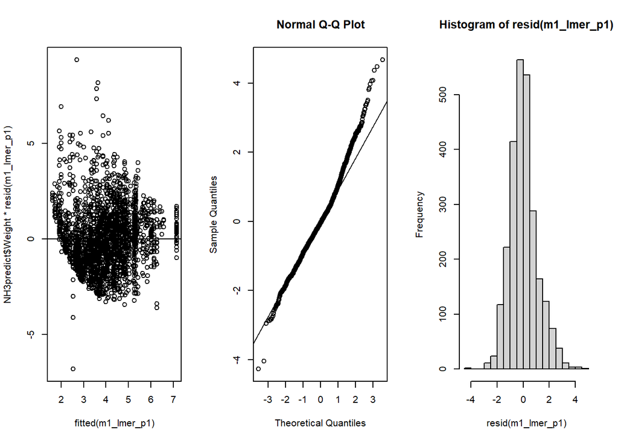

NH3-loss was different for different fertilisers (F(3, 2531) =301.83, p <0.001), as were the emissions from different application methods (F(3, 2402) =36.21, p <0.001). Laboratory measurements were significantly different from the measurements taken from the field (F(1, 490) =37.67, p <0.001). Measurement method also explained variation in NH3 emissions (F(6, 357) =4.65, p <0.001).

The pairwise-comparisons of factor-level effects can be seen below. The comparisons are made to urea (in Fertiliser), Broadcast (in Application), Micromet (in Method), and Outdoor (in Place). The estimates are given in the sqrt(x+4) -scale.

```
## Linear mixed model fit by REML. t-tests use Satterthwaite's method [
## lmerModLmerTest]
## Formula: sqrt(NH3loss + 4) ~ Fertiliser + Application + Method + Place +
##     (1 | Ref)
##    Data: NH3predict
## Weights: Weight
## Control: lmerControl(optimizer = "bobyqa")
##
## REML criterion at convergence: 8012.6
##
## Scaled residuals:
##     Min      1Q  Median      3Q     Max
## -3.1501 -0.6341 -0.0502  0.5629  4.6909
##
## Random effects:
##  Groups   Name        Variance Std.Dev.
##  Ref      (Intercept) 0.9987   0.9994
##  Residual             1.7340   1.3168
## Number of obs: 2596, groups:  Ref, 257
##
## Fixed effects:
##                             Estimate Std. Error         df t value Pr(>|t|)
## (Intercept)                4.768e+00  1.739e-01  5.408e+02  27.416  < 2e-16 ***
## FertiliserUAN             -5.239e-01  1.512e-01  2.565e+03  -3.466 0.000536 ***
## Fertiliserammonium+1      -9.897e-01  7.814e-02  2.560e+03 -12.666  < 2e-16 ***
## Fertiliserammonium+2      -1.977e+00  6.598e-02  2.530e+03 -29.970  < 2e-16 ***
## ApplicationIncorporated   -8.601e-01  8.662e-02  2.529e+03  -9.930  < 2e-16 ***
## ApplicationInjected       -1.086e+00  3.005e-01  2.578e+03  -3.614 0.000307 ***
## ApplicationLiquid         -3.585e-01  1.199e-01  2.132e+03  -2.990 0.002818 **
## Method15N                 -1.603e+00  5.137e-01  2.223e+03  -3.120 0.001830 **
## MethodClosed chamber      -9.124e-01  2.162e-01  4.555e+02  -4.221 2.94e-05 ***
## MethodDrager-Tube         -9.071e-01  3.929e-01  1.991e+02  -2.309 0.021985 *
## MethodSemi-open           -1.775e-01  2.881e-01  2.942e+02  -0.616 0.538160
## MethodVentilated chambers -5.903e-01  1.994e-01  8.297e+02  -2.960 0.003159 **
## MethodWindtunnel          -7.685e-03  2.816e-01  3.602e+02  -0.027 0.978240
## PlaceLab                   9.046e-01  1.474e-01  4.902e+02   6.138 1.73e-09 ***
## ---
## Signif. codes:  0 '***' 0.001 '**' 0.01 '*' 0.05 '.' 0.1 ' ' 1
```

The effect sizes (marginal means) for each category of each factor are presented below, parametrised to urea (in Fertiliser), Broadcast (in Application), Micromet (in Method), and Outdoor (in Place). The effect sizes are given at the back-transformed scale (NH3-loss %).

```
##         Factor               Level    Effect       SE        df   lower.CL
## 1   Fertiliser               urea+ 18.737420 1.661882  734.2675 15.5918523
## 2   Fertiliser                 UAN 14.015294 1.936768 1514.3098 10.4165454
## 3   Fertiliser          ammonium+1 10.278277 1.415111  959.1832  7.6362392
## 4   Fertiliser          ammonium+2  3.789477 1.025537  921.8696  1.9068273
## 5  Application           Broadcast 18.737420 1.661882  734.2675 15.5918523
## 6  Application        Incorporated 11.274486 1.491182 1008.3591  8.4884544
## 7  Application            Injected  9.559096 2.546567 5014.2440  5.0262540
## 8  Application              Liquid 15.446939 1.798243 1039.8260 12.0784035
## 9       Method            Micromet 18.737420 1.661882  734.2675 15.5918523
## 10      Method                 15N  6.020957 3.085296 7981.9925  0.8855118
## 11      Method      Closed chamber 10.868789 1.132211  369.3960  8.7257435
## 12      Method         Drager-Tube 10.909806 2.733087  199.3014  6.0073646
## 13      Method           Semi-open 17.075848 2.123522  298.9717 13.1040554
## 14      Method Ventilated chambers 13.456697 1.177628  529.8802 11.2199484
```

[output cut: 21 more lines]

The same effect sizes (and their 95% confidence interval) are shown below:

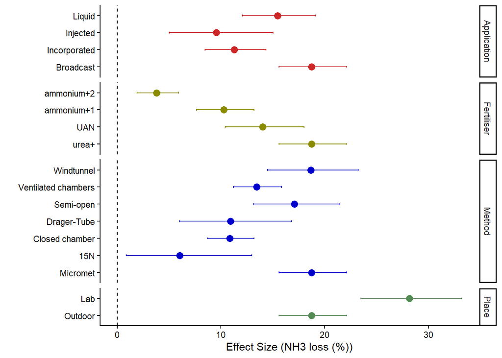

## Variance component analysis of A1 Base

Relative importance of each variable was estimated with a variance component analysis, where each categorical variable of model A1_Base was included as a random effect instead of a fixed effect. All other model specifications were kept the same.

```
##           grp        var1 var2      vcov     sdcor   var_perc
## 1         Ref (Intercept) <NA> 0.9821800 0.9910500 0.23635493
## 2      Method (Intercept) <NA> 0.1645703 0.4056726 0.03960271
## 3 Application (Intercept) <NA> 0.2053779 0.4531863 0.04942278
## 4  Fertiliser (Intercept) <NA> 0.6986648 0.8358617 0.16812892
## 5       Place (Intercept) <NA> 0.3674551 0.6061808 0.08842557
## 6    Residual        <NA> <NA> 1.7372821 1.3180600 0.41806508
```

Model A_Base explains 49.9 % of the variation in the data (conditional R2), with the fixed effects explaining 21.05 % (marginal R2). The R2-values for linear mixed effects model were calculated according to Nagakawa & Schielzeth (2013).

## Model A_Application rate

In model A_Application rate, as in all models following, we applied a linear model using fitted values from Model A_Base as an offset variable, to account for the variation explained by the factors already estimated in Model A_Base. As in Model A_Base, we transformed the response variable (NH3-loss %) with a squareroot-transformation with a constant of 4. The model was also weighted the analysis with the same weights as Model 1 to account for heteroscedasticity. This same structure was used in all following models.

The sole explanatory variable in Model A_Application rate was application rate (kg/ha).

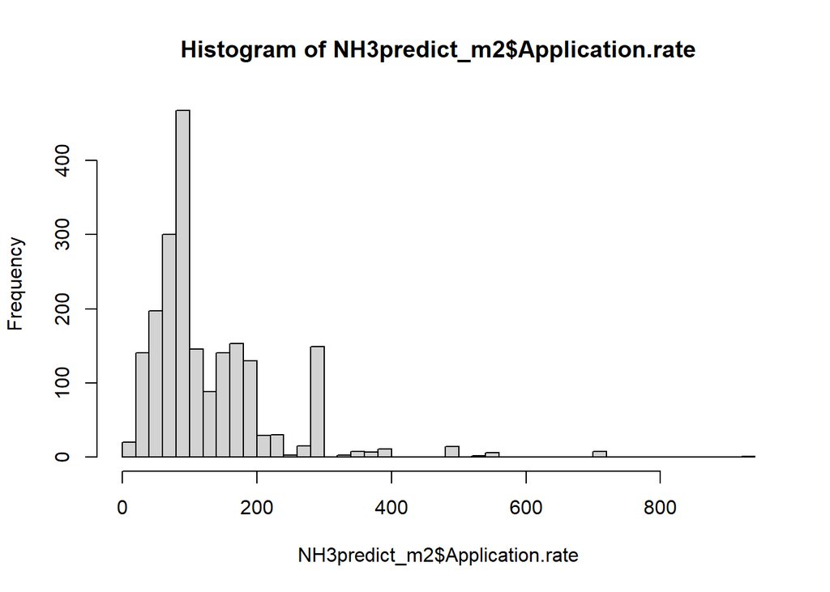

The model as it was applied can be seen below:

```r
# Model
m2_lm <- lm(sqrt(NH3loss+4) ~ Application.rate + offset(M1_fit),
            weights=Weight,
            data=NH3predict_m2)
```

The model assumptions can be seen below:

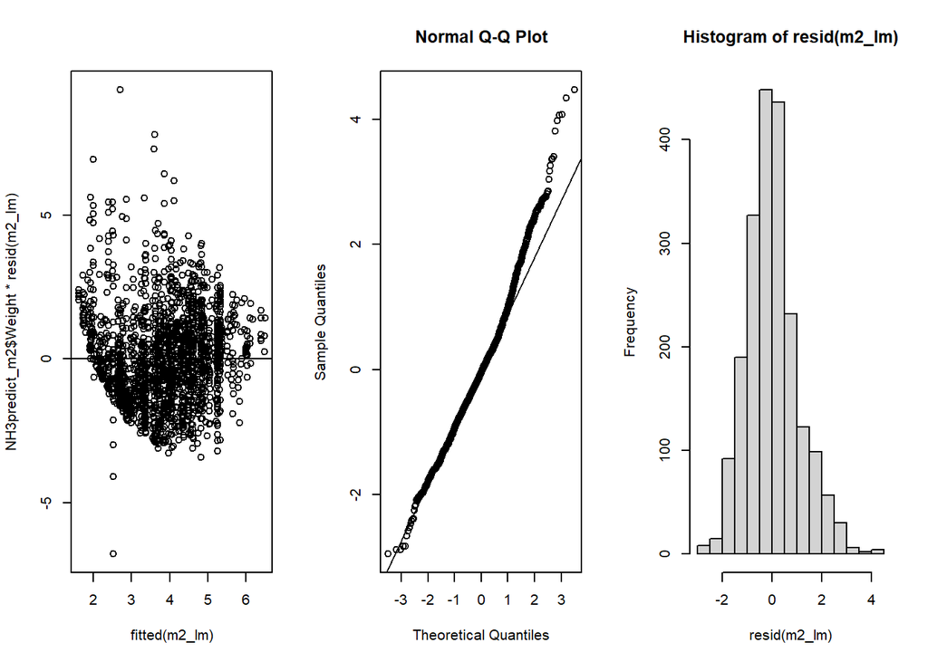

Application rate did not significantly explain variation in NH3-emissions (F(1, 2067) =0.12, p = 0.729). There was a statistically non-significant positive trend between Application rate and NH3-emissions ($\beta$+/-SE = 8^{-5} +/- 2.2^{-4}).

Full model output can be seen below:

```
##
## Call:
## lm(formula = sqrt(NH3loss + 4) ~ Application.rate + offset(M1_fit),
##     data = NH3predict_m2, weights = Weight)
##
## Weighted Residuals:
##     Min      1Q  Median      3Q     Max
## -4.1401 -0.8473 -0.0713  0.7438  5.9672
##
## Coefficients:
##                    Estimate Std. Error t value Pr(>|t|)
## (Intercept)      -1.259e-02  3.530e-02  -0.357    0.721
## Application.rate  7.681e-05  2.218e-04   0.346    0.729
##
## Residual standard error: 1.258 on 2067 degrees of freedom
## Multiple R-squared:  5.801e-05,  Adjusted R-squared:  -0.0004258
## F-statistic: 0.1199 on 1 and 2067 DF,  p-value: 0.7292
```

Application rate explains -0.04 % of residual variation in NH3-emissions (adjusted R-squared). (Note: Adjusted R-squared is manually adjusted to incorporate the offset-variable, and thus not consistent with the adjusted R-squared from the above model output.)

Figure below is a linear approximation of the effect of Application rate on NH3-emissions (linear slope back-transformed from the square-root scale).

[figure not shown]

## Model A_Soil pH

Soil pH was binarised into categories, where soils with pH>7.0 were categorised as chalky, and ph<=7.0 as normal. The number of observations in each group and their frequency distribution can be seen below.

```
##   pH_cat    N
## 1 normal 1509
## 2 chalky  991
```

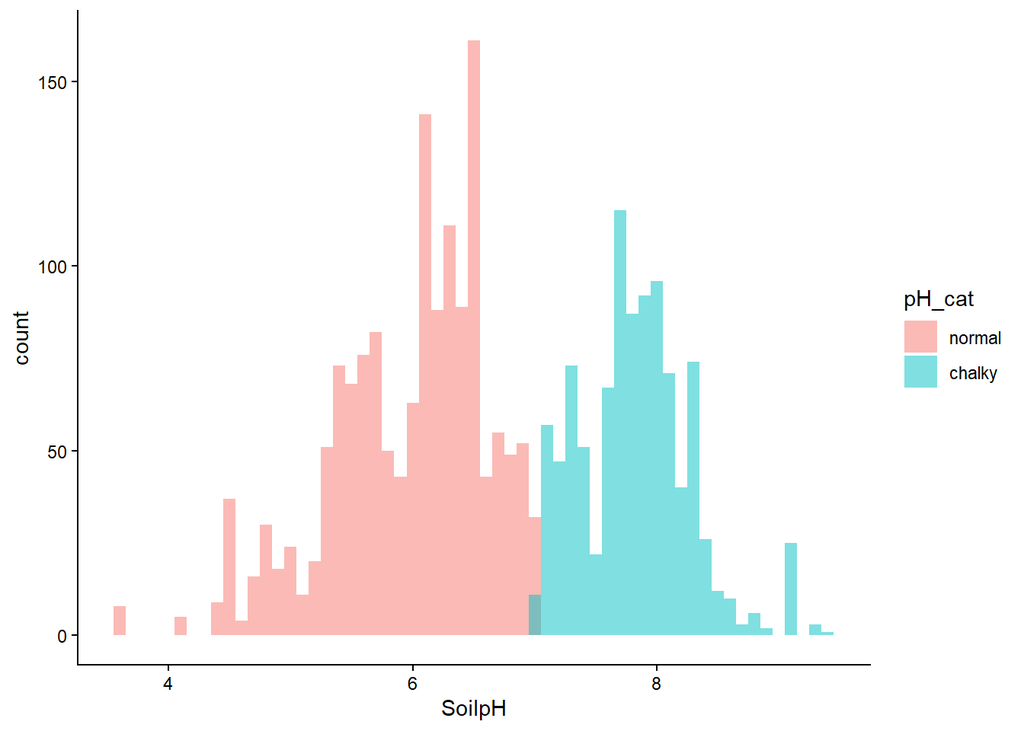

Model A_Soil pH followed the structure of Model A_Application rate. We added Soil pH, Fertiliser type, and the interaction between the two as fixed factors. In this model, Fertiliser types were used to identify differences between pH-categories, not to analyse the effect of Fertiliser on its own - the offset of Model A_Base removes the variation explained by Fertilisers otherwise.

```r
# Model
m3_lm <- lm(sqrt(NH3loss+4) ~ Fertiliser * pH_cat + offset(M1_fit),
            weights=Weight,
            data=NH3predict_m3)
```

The heteroscedasticity and normality of errors were as below:

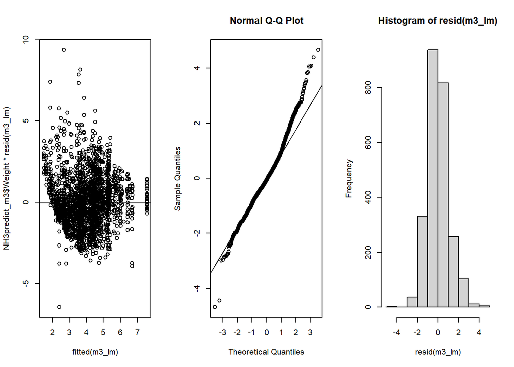

The effect of soil pH on NH3-emissions was dependent on the Fertiliser types (F(3, 2492) =22.38, p <0.001). Soil pH also had an independent effect on NH3 emissions (F(1, 2492) =28.85, p <0.001).

Full anova-table can be seen below:

```
## Analysis of Variance Table
##
## Response: sqrt(NH3loss + 4)
##                     Df Sum Sq Mean Sq F value    Pr(>F)
## Fertiliser           3    0.0   0.004  0.0025    0.9998
## pH_cat               1   45.2  45.168 28.8523 8.535e-08 ***
## Fertiliser:pH_cat    3  105.1  35.029 22.3756 2.707e-14 ***
## Residuals         2492 3901.2   1.565
## ---
## Signif. codes:  0 '***' 0.001 '**' 0.01 '*' 0.05 '.' 0.1 ' ' 1
```

Full model output can be seen below:

```
##
## Call:
## lm(formula = sqrt(NH3loss + 4) ~ Fertiliser * pH_cat + offset(M1_fit),
##     data = NH3predict_m3, weights = Weight)
##
## Weighted Residuals:
##     Min      1Q  Median      3Q     Max
## -4.2981 -0.7955 -0.0731  0.7326  6.1656
##
## Coefficients:
##                                    Estimate Std. Error t value Pr(>|t|)
## (Intercept)                        0.008755   0.031533   0.278   0.7813
## FertiliserUAN                     -0.101569   0.105167  -0.966   0.3342
## Fertiliserammonium+1              -0.443132   0.078635  -5.635 1.94e-08 ***
## Fertiliserammonium+2              -0.134458   0.057957  -2.320   0.0204 *
## pH_catchalky                      -0.020608   0.049865  -0.413   0.6794
## FertiliserUAN:pH_catchalky         0.326750   0.186396   1.753   0.0797 .
## Fertiliserammonium+1:pH_catchalky  0.870648   0.112795   7.719 1.69e-14 ***
## Fertiliserammonium+2:pH_catchalky  0.435200   0.100943   4.311 1.69e-05 ***
## ---
## Signif. codes:  0 '***' 0.001 '**' 0.01 '*' 0.05 '.' 0.1 ' ' 1
##
## Residual standard error: 1.251 on 2492 degrees of freedom
## Multiple R-squared:  0.03709,    Adjusted R-squared:  0.03438
## F-statistic: 13.71 on 7 and 2492 DF,  p-value: < 2.2e-16
```

The model explained 3.4 % of the residual variation in NH3-loss.

### Combining A_Base and A_Soil pH

For acquiring estimates for Soil pH in different fertiliser types at the same time, and same scale as the base-model, we added Soil pH and the interaction between pH and FertiliserType into the initial model. Please note this model has less data than Model A_Base, and as it includes new parameters, the estimates change slightly.

The effect sizes (marginal means) for the interaction can be seen below. The effect sizes are given at the back-transformed scale (NH3-loss %), parametrised to Fertiliser=urea+, Application=Broadcast, Method=Micromet, Place=outdoor, pH=normal.

```
##                Factor               Level    Effect        SE        df
## 1          Fertiliser               urea+ 17.919912 1.6946279  707.3647
## 2          Fertiliser                 UAN 11.544046 2.0312257 1817.6292
## 3          Fertiliser          ammonium+1  5.727903 1.2613889 1053.2575
## 4          Fertiliser          ammonium+2  2.498291 0.9780216  905.5284
## 5         Application           Broadcast 17.919912 1.6946279  707.3647
## 6         Application        Incorporated 10.281500 1.4894691  953.3628
## 7         Application            Injected  9.408981 2.5835509 4550.0871
## 8         Application              Liquid 14.632893 1.8001572  969.0485
## 9              Method            Micromet 17.919912 1.6946279  707.3647
## 10             Method                 15N  5.033829 2.8675313 7640.5251
## 11             Method      Closed chamber 10.448826 1.1134197  371.5260
## 12             Method         Drager-Tube  9.907021 2.5479929  197.3989
## 13             Method           Semi-open 17.535051 2.0563131  288.3401
## 14             Method Ventilated chambers 13.040500 1.1705462  512.7824
```

[output cut: 41 more lines]

The same effect sizes (and their 95% confidence interval) are shown below:

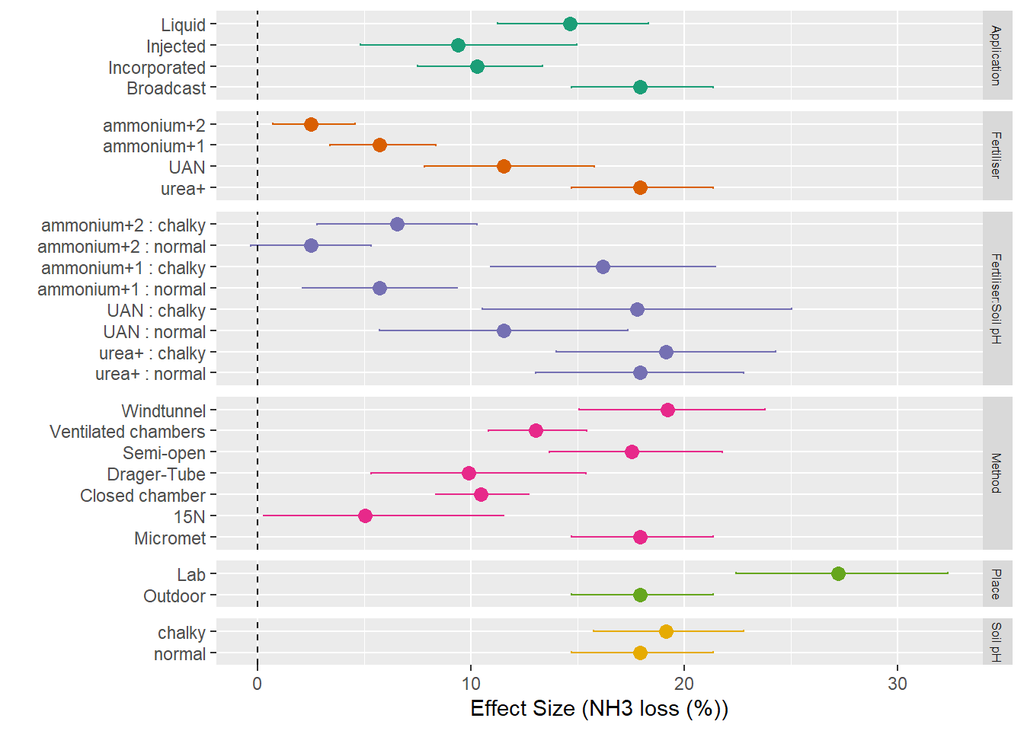

## Model A_Soil clay content

In Model A_Soil clay content, we explored the effect of Soil clay content (%) on NH3-loss (%).

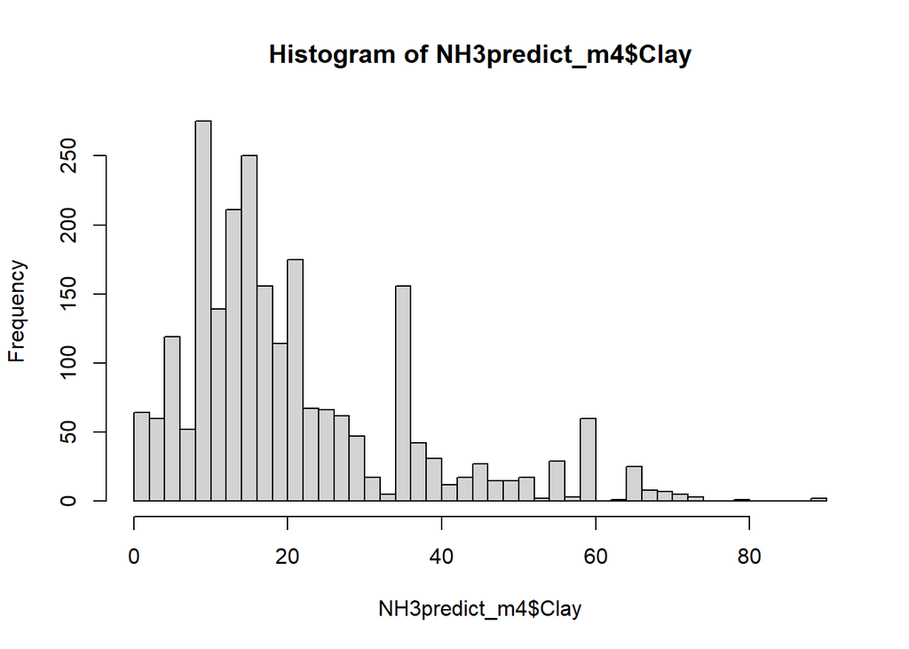

We used Soil clay content (%) as a continuous covariate and the sole explanatory variable in the model.

```r
# Model
m4_lm <- lm(sqrt(NH3loss +4) ~ Clay + offset(M1_fit),
            weights=Weight,
            data=NH3predict_m4)
```

The model assumptions (heteroscedasticity and normality of errors):

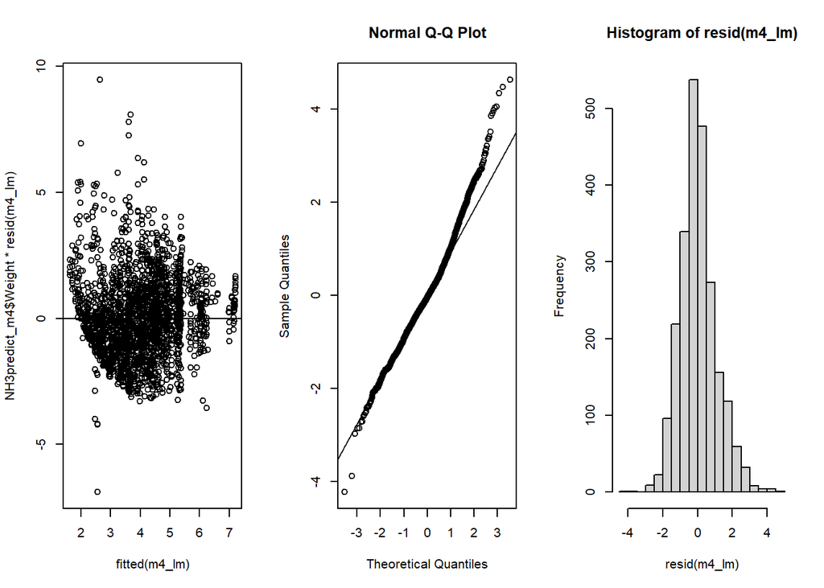

Soil clay content (%) affected NH3-loss (%) negatively ($\beta$+/-SE = -0.00311 +/- 0.00132, F(1, 2355) =5.58, p = 0.018).

Full model output can be seen below:

```
##
## Call:
## lm(formula = sqrt(NH3loss + 4) ~ Clay + offset(M1_fit), data = NH3predict_m4,
##     weights = Weight)
##
## Weighted Residuals:
##     Min      1Q  Median      3Q     Max
## -4.2057 -0.8108 -0.0631  0.7370  6.1101
##
## Coefficients:
##              Estimate Std. Error t value Pr(>|t|)
## (Intercept)  0.066252   0.034029   1.947   0.0517 .
## Clay        -0.003115   0.001318  -2.362   0.0182 *
## ---
## Signif. codes:  0 '***' 0.001 '**' 0.01 '*' 0.05 '.' 0.1 ' ' 1
##
## Residual standard error: 1.255 on 2355 degrees of freedom
## Multiple R-squared:  0.002364,   Adjusted R-squared:  0.001941
## F-statistic: 5.581 on 1 and 2355 DF,  p-value: 0.01823
```

Figure below is a linear approximation of the effect of Soil Clay content (%) on NH3-emissions (linear slope back-transformed from the square-root scale).

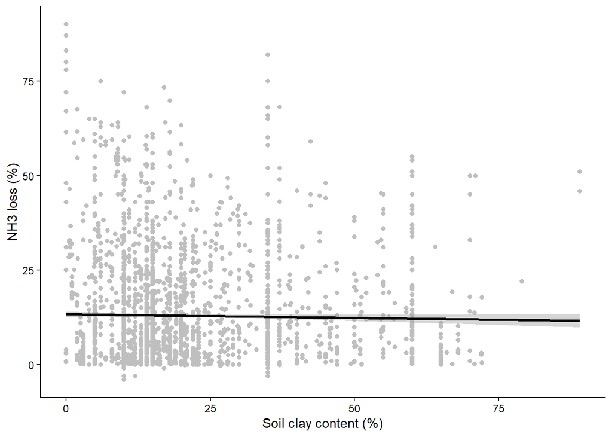

Test to see if a exponential function provides a better fit for the Clay data. The fit and parameters c and d were fitted a non-linear least-squares model.

```
##
## Formula: NH3loss ~ c * exp(d * (Clay))
##
## Parameters:
##    Estimate Std. Error t value Pr(>|t|)
## c 16.195873   0.605880  26.731  < 2e-16 ***
## d -0.004563   0.001584  -2.882  0.00399 **
## ---
## Signif. codes:  0 '***' 0.001 '**' 0.01 '*' 0.05 '.' 0.1 ' ' 1
##
## Residual standard error: 15.52 on 2355 degrees of freedom
##
## Number of iterations to convergence: 15
## Achieved convergence tolerance: 1.49e-08
```

The fitted relationship is as below:

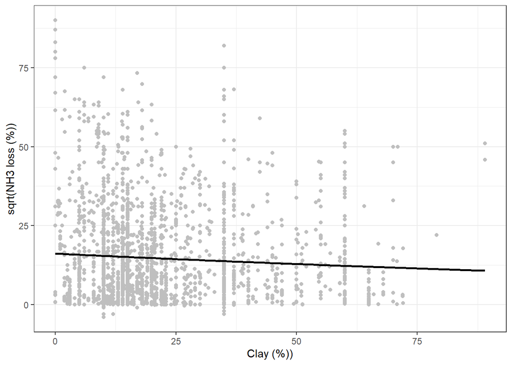

```r
# Transforming the Clay values to exp-scale
NH3predict_m4$Clay.exp <- coef(MR_nls_clay)[[1]]*exp(coef(MR_nls_clay)[[2]]*NH3predict_m4$Clay)
```

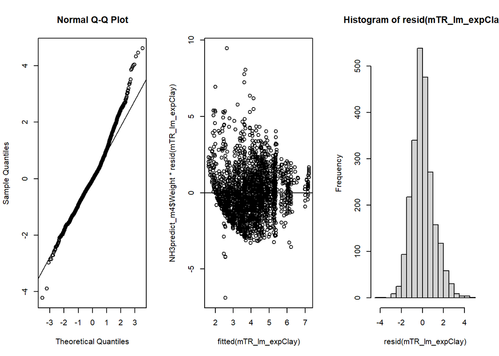

```
##
## Call:
## lm(formula = sqrt(NH3loss + 4) ~ Clay.exp + offset(M1_fit), data = NH3predict_m4,
##     weights = Weight)
##
## Weighted Residuals:
##     Min      1Q  Median      3Q     Max
## -4.2095 -0.8093 -0.0600  0.7366  6.1039
##
## Coefficients:
##             Estimate Std. Error t value Pr(>|t|)
## (Intercept) -0.74203    0.30334  -2.446   0.0145 *
## Clay.exp     0.05037    0.02054   2.453   0.0142 *
## ---
## Signif. codes:  0 '***' 0.001 '**' 0.01 '*' 0.05 '.' 0.1 ' ' 1
##
## Residual standard error: 1.254 on 2355 degrees of freedom
## Multiple R-squared:  0.002548,   Adjusted R-squared:  0.002125
## F-statistic: 6.016 on 1 and 2355 DF,  p-value: 0.01425
```

## Model A_Soil organic carbon

Soil organic carbon (g/kg) was modeled as a continuous variable. Most soils in the data were mineral (with a cutoff of 120 g/kg SOC), with only 3 organic soils in the dataset.

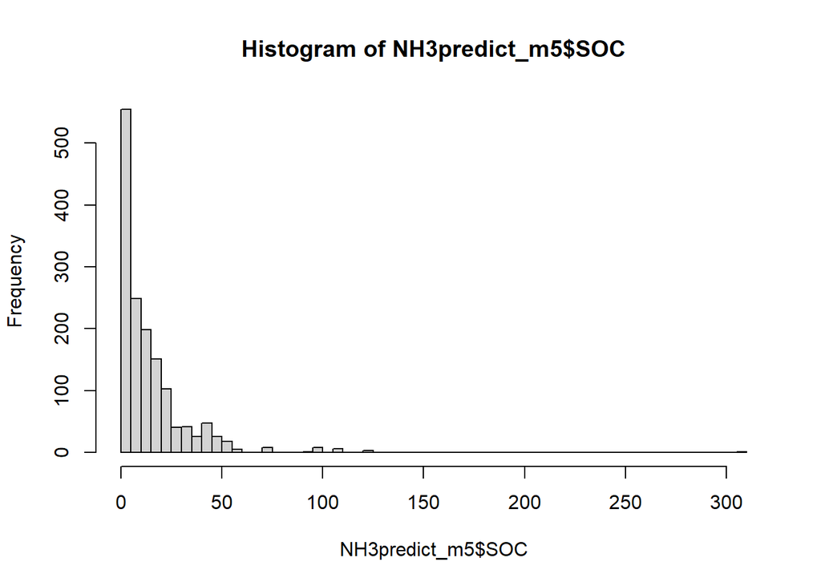

We used Soil organic carbon (g/kg) as a sole continuous covariate in the model.

```r
# Model
m5_lm <- lm(sqrt(NH3loss+4) ~ SOC + offset(M1_fit),
            weights=Weight,
            data=NH3predict_m5)
```

The model assumptions (heteroscedasticity and normality of errors):

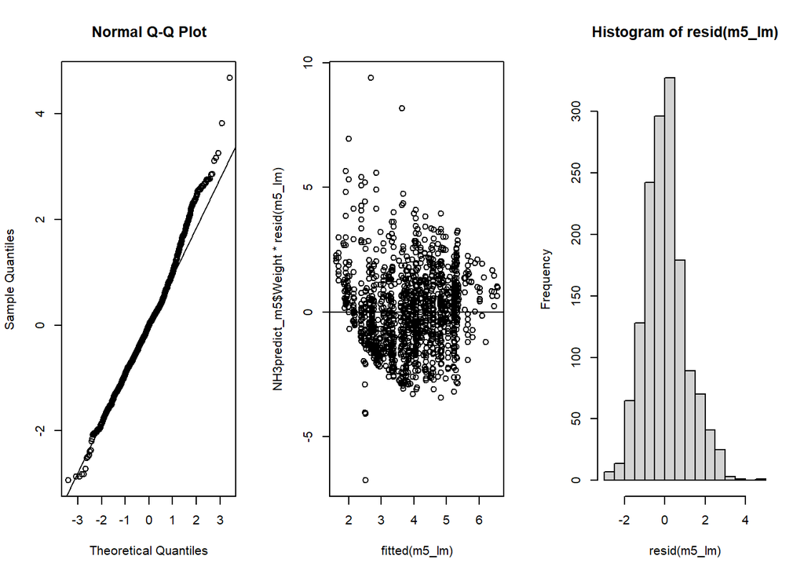

There was no effect of Soil organic carbon (g/kg) on NH3 loss (F(1, 1486) =0.3, p = 0.582).

Full model output can be seen below:

```
##
## Call:
## lm(formula = sqrt(NH3loss + 4) ~ SOC + offset(M1_fit), data = NH3predict_m5,
##     weights = Weight)
##
## Weighted Residuals:
##     Min      1Q  Median      3Q     Max
## -4.1178 -0.8316 -0.0109  0.7456  6.1811
##
## Coefficients:
##               Estimate Std. Error t value Pr(>|t|)
## (Intercept)  0.0006080  0.0298747   0.020    0.984
## SOC         -0.0006835  0.0012400  -0.551    0.582
##
## Residual standard error: 1.241 on 1486 degrees of freedom
## Multiple R-squared:  0.0002044,  Adjusted R-squared:  -0.0004684
## F-statistic: 0.3039 on 1 and 1486 DF,  p-value: 0.5815
```

Adjusted R2-value of the model was 0, and multiple R2 was 2.04^{-4}. The negative adjusted R2-value indicates that the amount of variation accounted for by Soil organic carbon is negligible. In practice, soil organic carbon explains no variation in the data.

Figure below is a linear approximation of the effect of Soil organic carbon (g/kg) on NH3-emissions (linear slope back-transformed from the square-root scale).

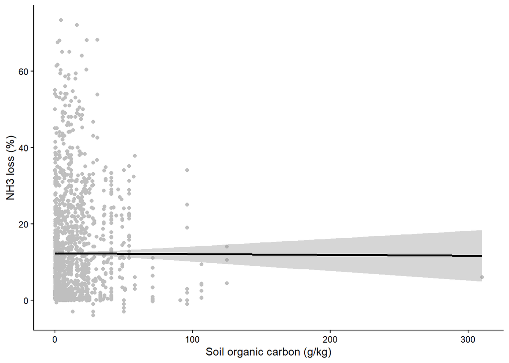

## Model A_Cover

```
##    Cover    N
## 1   None 1516
## 2 Arable  730
## 3  Grass  332
## 4  Other   18
```

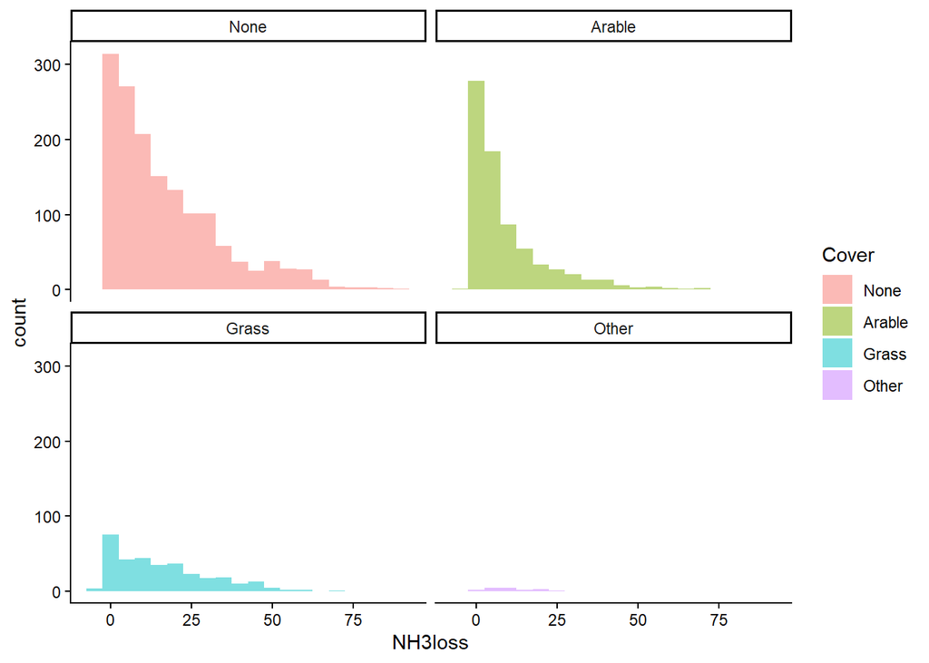

We added Cover as a fixed factor and a sole explanatory variable in the model.

```r
# Model
m6_lm <- lm(sqrt(NH3loss+4) ~ Cover + offset(M1_fit),
            weights=Weight,
            data=NH3predict_m6)
```

The model assumptions (heteroscedasticity and normality of errors):

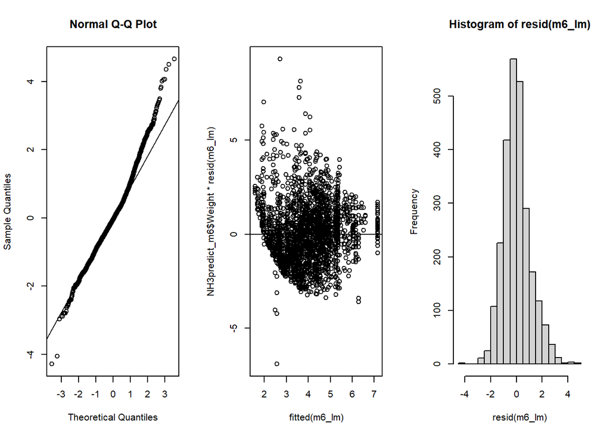

The cover categories (none, arable, grass) did not significantly differ from one another in NH3-emissions (F(3, 2592) =0.65, p = 0.581).

Full model output can be seen below:

```
##
## Call:
## lm(formula = sqrt(NH3loss + 4) ~ Cover + offset(M1_fit), data = NH3predict_m6,
##     weights = Weight)
##
## Weighted Residuals:
##     Min      1Q  Median      3Q     Max
## -4.2165 -0.8333 -0.0761  0.7427  6.1612
##
## Coefficients:
##             Estimate Std. Error t value Pr(>|t|)
## (Intercept)  0.01209    0.02558   0.473    0.637
## CoverArable -0.04511    0.04105  -1.099    0.272
## CoverGrass   0.02958    0.05907   0.501    0.617
## CoverOther  -0.06783    0.22292  -0.304    0.761
##
## Residual standard error: 1.264 on 2592 degrees of freedom
## Multiple R-squared:  0.0007544,  Adjusted R-squared:  -0.0004022
## F-statistic: 0.6523 on 3 and 2592 DF,  p-value: 0.5815
```

Adjusted R2-value of the model was -4^{-4}, and multiple R2 was 7.5^{-4}. The negative adjusted R2-value indicates that the amount of variation accounted for by Cover crops is negligible. In practice, cover crops explain no variation in the data.

The effect sizes (marginal means) of % NH3-loss for each cover category can be seen below.

```
##    Cover   emmean         SE   df lower.CL upper.CL
## 1   None 3.943894 0.02558483 2592 3.893725 3.994063
## 2 Arable 3.898787 0.03210522 2592 3.835832 3.961741
## 3  Grass 3.973475 0.05324518 2592 3.869068 4.077883
## 4  Other 3.876069 0.22144457 2592 3.441842 4.310295
```

```
## `height` was translated to `width`.
```

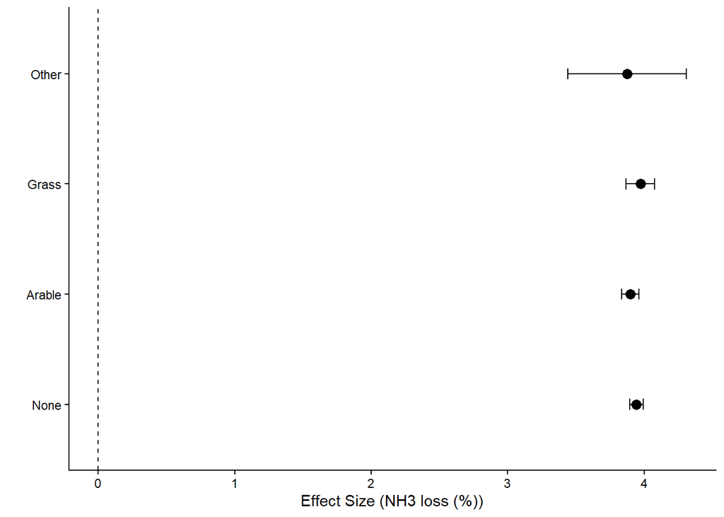

## Model A_Air temperature and rainfall

AirTemperature over the duration of the experiment (Celcius) and mean rainfall over the experimental period (mm) were analysed together, to explore interactions between the two variables. The frequency distributions of the two variables can be seen below.

There are 934 observations in the analysis.

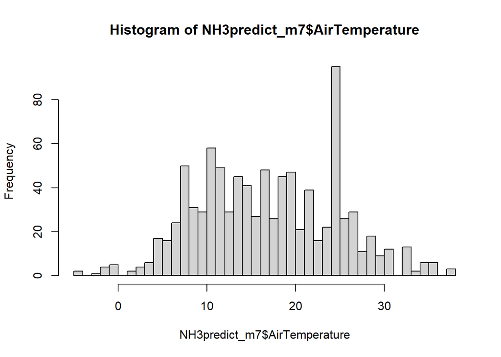

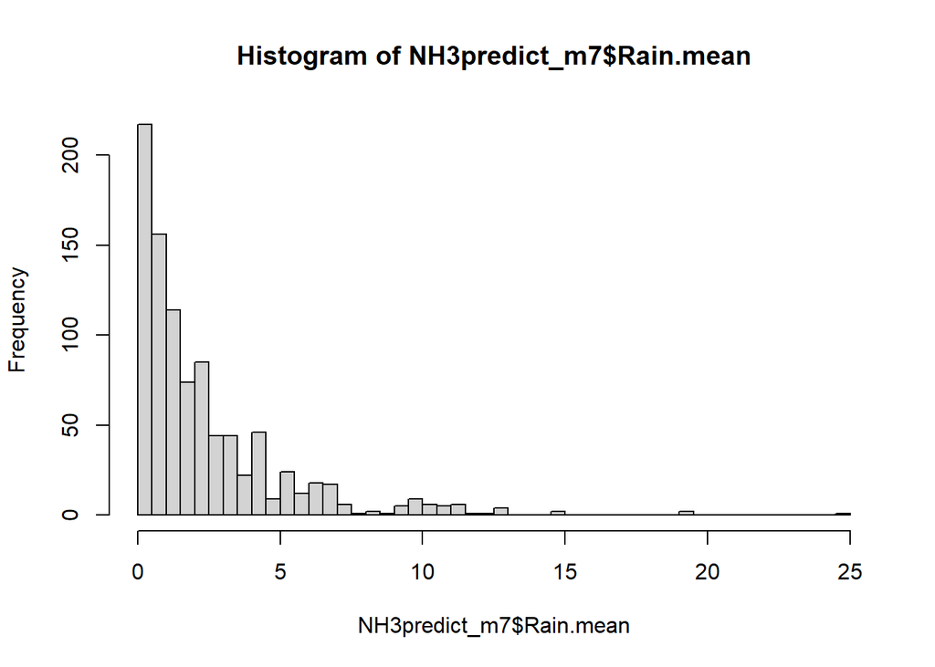

```r
# Model
mTR_lm <- lm(sqrt(NH3loss+4) ~ AirTemperature * Rain.mean + offset(M1_fit),
             weights=Weight,
             data=NH3predict_m7)
```

The model assumptions (heteroscedasticity and normality of errors):

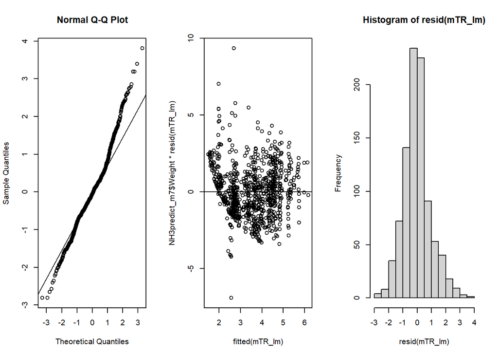

Full model output can be seen below:

```
##
## Call:
## lm(formula = sqrt(NH3loss + 4) ~ AirTemperature * Rain.mean +
##     offset(M1_fit), data = NH3predict_m7, weights = Weight)
##
## Weighted Residuals:
##     Min      1Q  Median      3Q     Max
## -4.2177 -0.7770 -0.0801  0.6759  5.9659
##
## Coefficients:
##                           Estimate Std. Error t value Pr(>|t|)
## (Intercept)              -0.015225   0.088524  -0.172   0.8635
## AirTemperature            0.004743   0.004779   0.993   0.3211
## Rain.mean                -0.068913   0.035517  -1.940   0.0526 .
## AirTemperature:Rain.mean  0.002136   0.001564   1.365   0.1725
## ---
## Signif. codes:  0 '***' 0.001 '**' 0.01 '*' 0.05 '.' 0.1 ' ' 1
##
## Residual standard error: 1.203 on 930 degrees of freedom
## Multiple R-squared:  0.01042,    Adjusted R-squared:  0.00723
## F-statistic: 3.265 on 3 and 930 DF,  p-value: 0.02083
```

Air temperature and rainfall, and the interaction between the two explain 0.72 % of the variation in the data.

The marginally non-significant interaction between rainfall and temperature can be interpreted as the slope of air temperature increasing in steepness with increasing rainfall. This means that the effect of temperature is dependent on rainfall, and temperature only has an effect when rain is present.

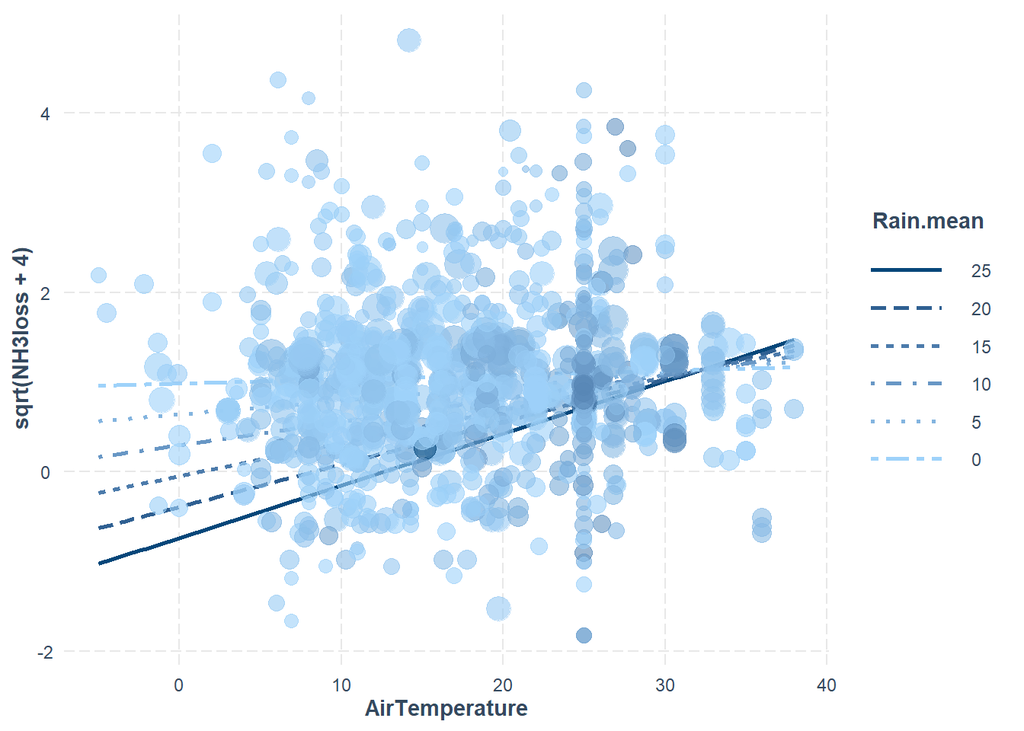

Similarly, the interaction can be interpreted from the perspective of rain: The association between rain and NH3 emissions changes from negative to slightly positive with increasing temperature.

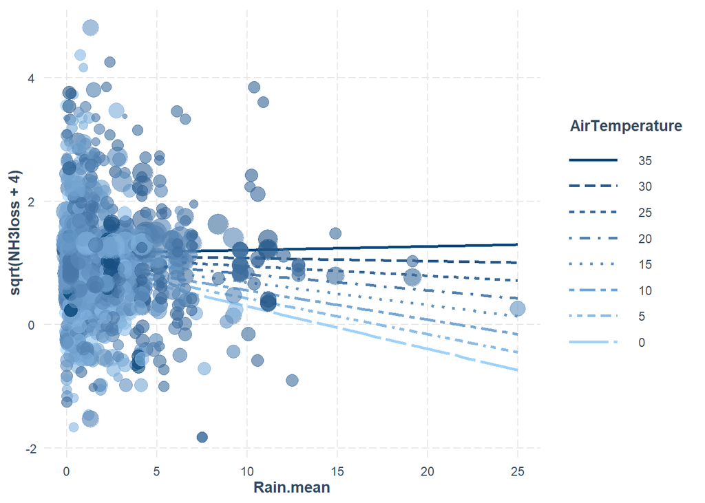

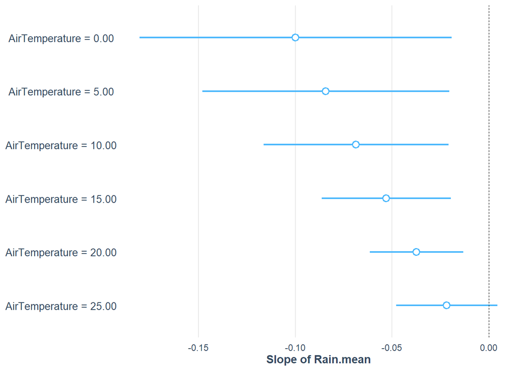

```
## JOHNSON-NEYMAN INTERVAL
##
## When AirTemperature is INSIDE the interval [1.00, 22.56], the slope of
## Rain.mean is p < .05.
##
## Note: The range of observed values of AirTemperature is [-5.00, 38.00]
```

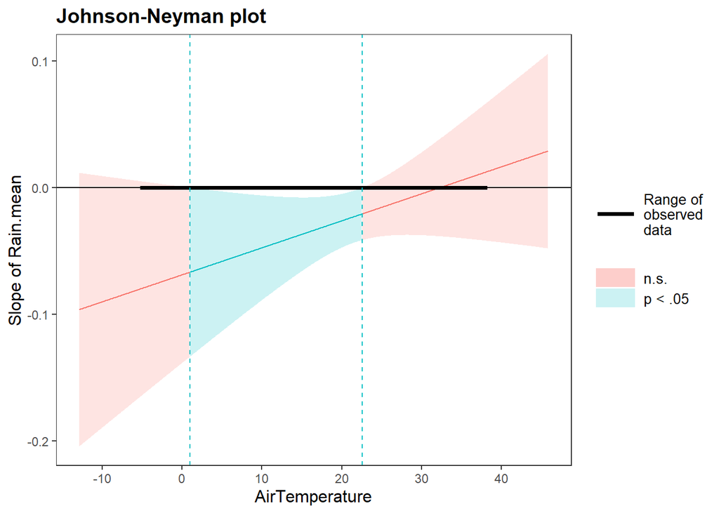

### A_Air temperature

Considering air temperature separately, there is a statistically significant effect of air temperature (F(1, 1887) =7.73, p = 0.005). Adjusted R2-value of the model was 0.00355, and multiple R2 was 0.00408. This means air temperature explains 0.355 % of the variation.

There are 1889 observations in the analysis.

The full model output with the slopes and their standard error can be seen below:

```
##
## Call:
## lm(formula = sqrt(NH3loss + 4) ~ AirTemperature + offset(M1_fit),
##     data = NH3predict_m7_2, weights = Weight)
##
## Weighted Residuals:
##     Min      1Q  Median      3Q     Max
## -4.1600 -0.8347 -0.0316  0.7566  6.0612
##
## Coefficients:
##                 Estimate Std. Error t value Pr(>|t|)
## (Intercept)    -0.146756   0.057307  -2.561  0.01052 *
## AirTemperature  0.007814   0.002810   2.781  0.00548 **
## ---
## Signif. codes:  0 '***' 0.001 '**' 0.01 '*' 0.05 '.' 0.1 ' ' 1
##
## Residual standard error: 1.265 on 1887 degrees of freedom
## Multiple R-squared:  0.004081,   Adjusted R-squared:  0.003553
## F-statistic: 7.732 on 1 and 1887 DF,  p-value: 0.005478
```

### A_Air temperature over first 7 days

There is no statistically significant effect of air temperature over the first 7 days of the experiment (F(1, 179) =2.69, p = 0.103). Adjusted R2-value of the model was 0.00928, and multiple R2 was 0.01478. This means air temperature over the first 7 days explains 0.928 % of the variation.

There are 181 observations in the analysis.

The full model output with the slopes and their standard error can be seen below:

```
##
## Call:
## lm(formula = sqrt(NH3loss + 4) ~ Temp.7d + offset(M1_fit), data = NH3predict_mA7,
##     weights = Weight)
##
## Weighted Residuals:
##     Min      1Q  Median      3Q     Max
## -4.0579 -0.7773  0.0908  0.8844  3.5790
##
## Coefficients:
##              Estimate Std. Error t value Pr(>|t|)
## (Intercept)  0.226650   0.140977   1.608    0.110
## Temp.7d     -0.014017   0.008553  -1.639    0.103
##
## Residual standard error: 1.238 on 179 degrees of freedom
## Multiple R-squared:  0.01478,    Adjusted R-squared:  0.00928
## F-statistic: 2.686 on 1 and 179 DF,  p-value: 0.103
```

### A_Mean daily rainfall

Considering mean rainfall separately, there is no statistically significant effect of rain (F(1, 1036) =1.57, p = 0.21). Adjusted R2-value of the model was 5.5^{-4}, and multiple R2 was 0.00152. Thus, rainfall doesn’t meaningfully explain any variation in the data.

There are 1038 observations in the analysis.

The full model output with the slopes and their standard error can be seen below:

```
##
## Call:
## lm(formula = sqrt(NH3loss + 4) ~ Rain.mean + offset(M1_fit),
##     data = NH3predict_m8, weights = Weight)
##
## Weighted Residuals:
##     Min      1Q  Median      3Q     Max
## -4.1703 -0.7694 -0.0770  0.6810  5.9448
##
## Coefficients:
##              Estimate Std. Error t value Pr(>|t|)
## (Intercept)  0.029624   0.034843   0.850    0.395
## Rain.mean   -0.012099   0.009643  -1.255    0.210
##
## Residual standard error: 1.198 on 1036 degrees of freedom
## Multiple R-squared:  0.001517,   Adjusted R-squared:  0.0005535
## F-statistic: 1.574 on 1 and 1036 DF,  p-value: 0.2099
```

### A_Rainfall over first 72 h

There is no statistically significant effect of rainfall during the first 72h of the experiment (F(1, 671) =0.1, p = 0.753). Adjusted R2-value of the model was -0.00134, and multiple R2 was 1.5^{-4}. Thus, rainfall during the first 72h doesn’t meaningfully explain any variation in the data.

There are 673 observations in the analysis.

The full model output with the slopes and their standard error can be seen below:

```
##
## Call:
## lm(formula = sqrt(NH3loss + 4) ~ Rain.72h + offset(M1_fit), data = NH3predict_R8,
##     weights = Weight)
##
## Weighted Residuals:
##     Min      1Q  Median      3Q     Max
## -4.1600 -0.8515 -0.0750  0.7693  5.9863
##
## Coefficients:
##               Estimate Std. Error t value Pr(>|t|)
## (Intercept)  0.0112796  0.0372465   0.303    0.762
## Rain.72h    -0.0008171  0.0025973  -0.315    0.753
##
## Residual standard error: 1.24 on 671 degrees of freedom
## Multiple R-squared:  0.0001475,  Adjusted R-squared:  -0.001343
## F-statistic: 0.09896 on 1 and 671 DF,  p-value: 0.7532
```

Figures below show a linear approximation of the effect of air temperature (Celcius) and mean rainfall (mm) on NH3-emissions (linear slope back-transformed from the square-root scale).

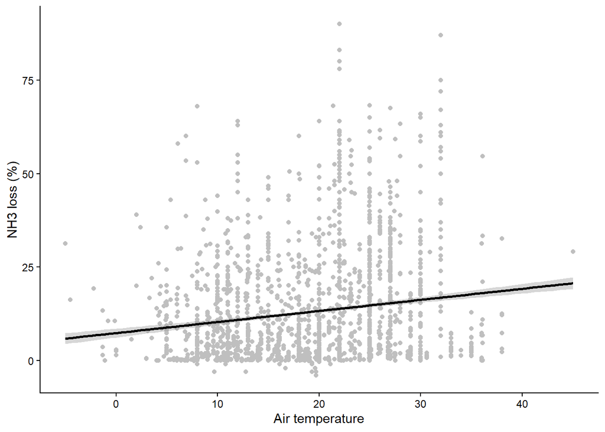

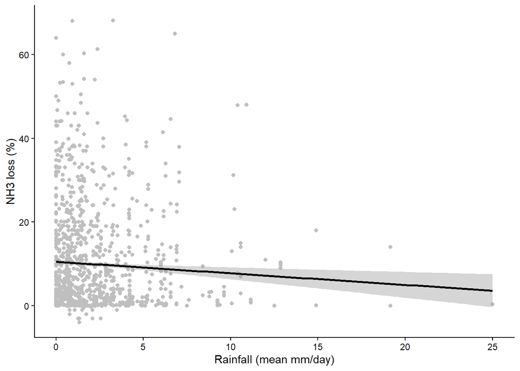

### A_Rainfall as a non-linear effect

We fitted an exponential function with parameters a and b to rainfall data. The equation is as follows:

$f(Rain.mean) = a * e^{(b*Rain.mean)}$

To test the fit and to estimate parameters a and b, we fitted a non-linear least-squares model.

```
##
## Formula: NH3loss ~ a * exp(b * (Rain.mean))
##
## Parameters:
##   Estimate Std. Error t value Pr(>|t|)
## a 11.57340    0.58608   19.75   <2e-16 ***
## b -0.03525    0.01727   -2.04   0.0416 *
## ---
## Signif. codes:  0 '***' 0.001 '**' 0.01 '*' 0.05 '.' 0.1 ' ' 1
##
## Residual standard error: 12.57 on 932 degrees of freedom
##
## Number of iterations to convergence: 12
## Achieved convergence tolerance: 1.49e-08
```

The fitted relationship is as below:

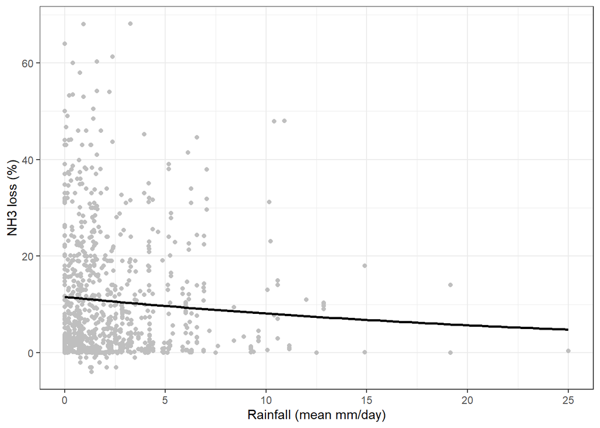

The RMSE (root mean square error) of the model was 12.5526708, which is on the same scale as mean NH3loss values in the data (10.7023381) indicating a poor fit of the model. (Error equal to the estimated value.)

We calculated new rain estimates on the exponential scale, with the estimated parameters taken into account, and ran the analysis with air temperature again, using the exponential Rain.mean values calculated using the coefficients (parameter estimates) from the non-linear least-squares fit above.

```r
# Transforming the Rain values to exp-scale
NH3predict_m7$Rain.exp <- coef(MR_nls)[[1]]*exp(coef(MR_nls)[[2]]*NH3predict_m7$Rain.mean)
```

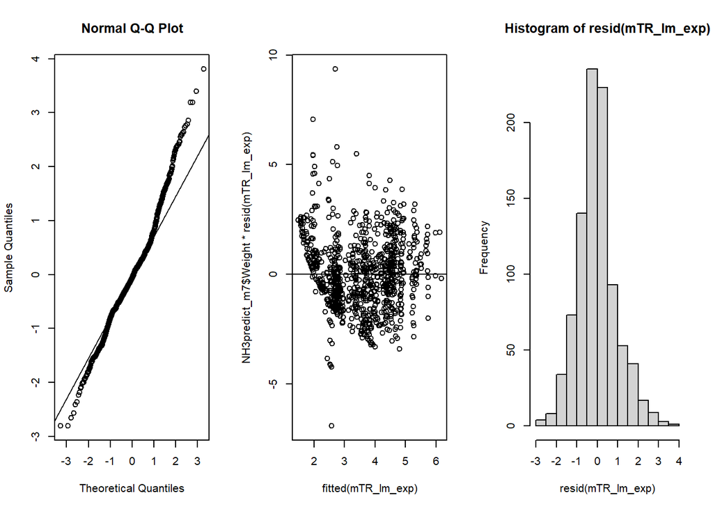

```
##
## Call:
## lm(formula = sqrt(NH3loss + 4) ~ AirTemperature * Rain.exp +
##     offset(M1_fit), data = NH3predict_m7, weights = Weight)
##
## Weighted Residuals:
##     Min      1Q  Median      3Q     Max
## -4.2184 -0.7753 -0.0888  0.6751  5.9672
##
## Coefficients:
##                          Estimate Std. Error t value Pr(>|t|)
## (Intercept)             -2.230926   1.108905  -2.012   0.0445 *
## AirTemperature           0.071650   0.048830   1.467   0.1426
## Rain.exp                 0.192016   0.101039   1.900   0.0577 .
## AirTemperature:Rain.exp -0.005783   0.004492  -1.287   0.1983
## ---
## Signif. codes:  0 '***' 0.001 '**' 0.01 '*' 0.05 '.' 0.1 ' ' 1
##
## Residual standard error: 1.203 on 930 degrees of freedom
## Multiple R-squared:  0.01036,    Adjusted R-squared:  0.007168
## F-statistic: 3.245 on 3 and 930 DF,  p-value: 0.02139
```

```
##
## Call:
## lm(formula = sqrt(NH3loss + 4) ~ AirTemperature + Rain.exp +
##     offset(M1_fit), data = NH3predict_m7, weights = Weight)
##
## Weighted Residuals:
##     Min      1Q  Median      3Q     Max
## -4.2307 -0.7967 -0.0784  0.6872  5.9649
##
## Coefficients:
##                 Estimate Std. Error t value Pr(>|t|)
## (Intercept)    -0.880446   0.359537  -2.449   0.0145 *
## AirTemperature  0.008972   0.003723   2.410   0.0162 *
## Rain.exp        0.068289   0.031184   2.190   0.0288 *
## ---
## Signif. codes:  0 '***' 0.001 '**' 0.01 '*' 0.05 '.' 0.1 ' ' 1
##
## Residual standard error: 1.204 on 931 degrees of freedom
## Multiple R-squared:  0.008597,   Adjusted R-squared:  0.006467
## F-statistic: 4.036 on 2 and 931 DF,  p-value: 0.01797
```

When non-linear rain is analysed separately, there is no effect of rain on NH3loss (F(1, 1036) =1.53, p = 0.216). See the slope estimate from below:

```
##
## Call:
## lm(formula = sqrt(NH3loss + 4) ~ Rain.exp + offset(M1_fit), data = NH3predict_m8,
##     weights = Weight)
##
## Weighted Residuals:
##     Min      1Q  Median      3Q     Max
## -4.1701 -0.7714 -0.0817  0.6786  5.9451
##
## Coefficients:
##             Estimate Std. Error t value Pr(>|t|)
## (Intercept) -0.37658    0.30593  -1.231    0.219
## Rain.exp     0.03531    0.02852   1.238    0.216
##
## Residual standard error: 1.198 on 1036 degrees of freedom
## Multiple R-squared:  0.001478,   Adjusted R-squared:  0.000514
## F-statistic: 1.533 on 1 and 1036 DF,  p-value: 0.2159
```